# Gaya Aran, 209636885; Nadav Weisler, 316493758

```r
require(rmarkdown)
require(dplyr)
require(ggpubr)
TARGET <- 0.5
NON_TARGET <- -0.5
```

# Part 1

## Question 1

```r
setwd("C:/Repos/Study/StatisticsForGraduateStudents/EX/ex1")
attentionDrivesEmotion <- read.csv("attention-drives-emotion-2019-exp1.csv")
```

## Question 2

Rated intensity of emotional response -> *reaction* Rated emotional intensity -> *intensity* Subject identity -> *id* Valence of image rated -> *ValenceContrast* Whether the image was a target or-non target -> *target*

## Question 3

```r
attentionDrivesEmotion$rating <-
  rowMeans(attentionDrivesEmotion[, c('intensity', 'reaction')], na.rm = TRUE)
```

## Question 4

```r
participants_count_before <- length(unique(attentionDrivesEmotion$id))

attentionDrivesEmotion <- attentionDrivesEmotion %>%
  filter((demand_intensity != 2) & (ValenceContrast != 0))

participants_removed <-
  (participants_count_before - length(unique(attentionDrivesEmotion$id)))
```

According to the R code, 15 participants were removed.

## Question 5

```r
attentionDrivesEmotion$z_rating <- with(attentionDrivesEmotion, scale(rating))
```

## Question 6

```r
attentionDrivesEmotion <- attentionDrivesEmotion %>%
  filter(abs(z_rating) < 2)
```

## Question 7

```r
dfSummary <- attentionDrivesEmotion %>%
group_by(id, target) %>%
  summarise(
    mean = mean(rating),
    sd = sd(rating),
    count = length(rating)
  )
```

[output not shown]

```r
sum(dfSummary[dfSummary$target == TARGET,]$count)
```

```
## [1] 160
```

160 is the total number of target trials left.

## Question 8

```r
gender_df <- read.csv("attention-drives-emotion-2019-exp1-subject-gender.csv")
gender_df <- gender_df[ , !(names(gender_df) %in% c("X"))]
uniqe_gender_names <- unique(gender_df$gender)
uniqe_gender_names
```

```
##  [1] "female"               "m"                    "Male"
##  [4] "Female"               "femail"               "male "
##  [7] "male"                 "Malle"                "Male to Female Trans"
## [10] "FEMALE"               "female "              "M"
## [13] "F"                    " Male"                "famale"
```

```r
gender_df$gender[grepl("Trans", gender_df$gender)] <- "O"
gender_df$gender[grepl("f", gender_df$gender)] <- "F"
gender_df$gender[grepl("F", gender_df$gender)] <- "F"
gender_df$gender[!grepl("F", gender_df$gender) &
                   !grepl("O", gender_df$gender)] <- "M"

length(gender_df$gender[gender_df$gender == "M"])
```

```
## [1] 36
```

```r
length(gender_df$gender[gender_df$gender == "F"])
```

```
## [1] 63
```

```r
length(gender_df$gender[gender_df$gender == "O"])
```

```
## [1] 1
```

36 Males, 63 Females and 1 Other.

## Question 9

```r
dfSummary <- merge(dfSummary, gender_df,by="id")
```

```r
genderSummery <- dfSummary %>%
group_by(gender) %>%
  summarise(
    mean = mean(mean),
    sd = mean(sd, na.rm = T)
  )
genderSummery
```

```
## # A tibble: 3 × 3
##   gender  mean    sd
##   <chr>  <dbl> <dbl>
## 1 F      3.45  1.43
## 2 M      3.36  1.28
## 3 O      0.792 0.541
```

## Question 10

```r
print(table(dfSummary$target))
```

```
##
## -0.5  0.5
##   84   83
```

```r
print(table(dfSummary$id))
```

```
##
##   1   2   3   4   6   7   8   9  10  13  14  15  16  17  18  19  20  22  23  24
##   2   2   2   2   2   2   2   2   2   2   2   2   2   2   2   2   2   2   2   2
##  26  27  28  29  30  31  32  33  34  35  37  38  39  40  41  42  43  44  45  46
##   2   2   2   2   2   2   2   2   2   2   2   2   2   2   2   2   2   2   2   2
##  47  48  49  50  51  53  54  55  56  58  59  60  62  63  64  65  66  67  70  72
##   2   2   2   2   2   2   2   2   2   2   2   2   2   2   2   2   2   2   2   2
##  73  75  76  77  78  79  80  81  82  83  84  86  87  88  89  90  91  93  94  95
##   2   2   1   2   2   2   2   2   2   2   2   2   2   2   2   2   2   2   2   2
##  96  98  99 100
##   2   2   2   2
```

```r
# After error msg in paired t.test we noticed there was a participant (id = 76)
# without target trials (after trial clean). we exclude this participant because
# paired t.test required both kinds of trials (target and non-target) for each
# participant.
dfSummary <- dfSummary[dfSummary$id != 76,]

t_test_Q10 <- t.test(x = dfSummary$mean[dfSummary$target == TARGET],
                     y = dfSummary$mean[dfSummary$target == NON_TARGET],
                     alternative = "greater", paired = TRUE, var.equal = TRUE)
t_test_Q10
```

```
##
##  Paired t-test
##
## data:  dfSummary$mean[dfSummary$target == TARGET] and dfSummary$mean[dfSummary$target == NON_TARGET]
## t = 1.9491, df = 82, p-value = 0.02735
## alternative hypothesis: true mean difference is greater than 0
## 95 percent confidence interval:
##  0.0413983       Inf
## sample estimates:
## mean difference
##       0.2826927
```

As it was predicted by the authors, the target stimuli found to have greater intensity rating than non-target stimuli (target: M = 3.55, SD = 2.13, non-target: M = 3.27, SD = 1.65). In other words, the intensity of emotion reported by the participant for the spatially cued objects compared to non-cued objects (targets and non-targets) was significantly greater (t(82) = 1.95, p-value = 0.027).

## Question 11

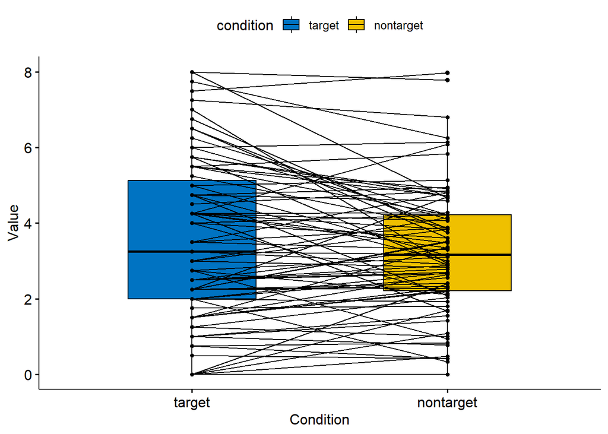

```r
target <- dfSummary[dfSummary$target == TARGET, ]$mean
nontarget <- dfSummary[dfSummary$target == NON_TARGET, ]$mean
df_rating <- data.frame(target = target, nontarget = nontarget)

ggpaired(df_rating, cond1 = "target", cond2 = "nontarget",
    fill = "condition", palette = "jco")
```

# Part 2

```r
set.seed(6)
```

## Question 1

```r
t_test_sim <- function(M1, M2, S1, S2, N1, N2) {
  group_1 <- rnorm(N1, M1, S1)
  group_2 <- rnorm(N2, M2, S2)
  result <- t.test(group_1, group_2, alternative = "two.sided", var.equal = T)
  t_statistic <- result$statistic
  p_value <- result$p.value
#  degrees_freedom <- result$parameter
#  print(degrees_freedom)
  return(data.frame(t_statistic, p_value))
}
results <- t_test_sim(0, 0, 1, 1, 50, 50)
results
```

```
##   t_statistic   p_value
## t   0.9369796 0.3510724
```

## Question 2

```r
resultsA <- data.frame(matrix(NA, ncol=2, nrow=1000))
colnames(resultsA) <- c("t_statistic", "p_value")
resultsB <- data.frame(matrix(NA, ncol=2, nrow=1000))
colnames(resultsB) <- c("t_statistic", "p_value")
resultsC <- data.frame(matrix(NA, ncol=2, nrow=1000))
colnames(resultsC) <- c("t_statistic", "p_value")
resultsD <- data.frame(matrix(NA, ncol=2, nrow=1000))
colnames(resultsD) <- c("t_statistic", "p_value")
resultsE <- data.frame(matrix(NA, ncol=2, nrow=1000))
colnames(resultsE) <- c("t_statistic", "p_value")
resultsF <- data.frame(matrix(NA, ncol=2, nrow=1000))
colnames(resultsF) <- c("t_statistic", "p_value")

for (i in 1:1000){
  resultsA[i,] <- t_test_sim(0, 0, 1, 1, 30, 30)
  resultsB[i,] <- t_test_sim(0, 0, 1, 3, 30, 30)
  resultsC[i,] <- t_test_sim(0, 0, 1, 1, 90, 90)
  resultsD[i,] <- t_test_sim(0.5, 0, 1, 1, 30, 30)
  resultsE[i,] <- t_test_sim(sqrt(5) * 0.5, 0, 1, 3, 30, 30)
  resultsF[i,] <- t_test_sim(0.5, 0, 1, 1, 90, 90)
}
```

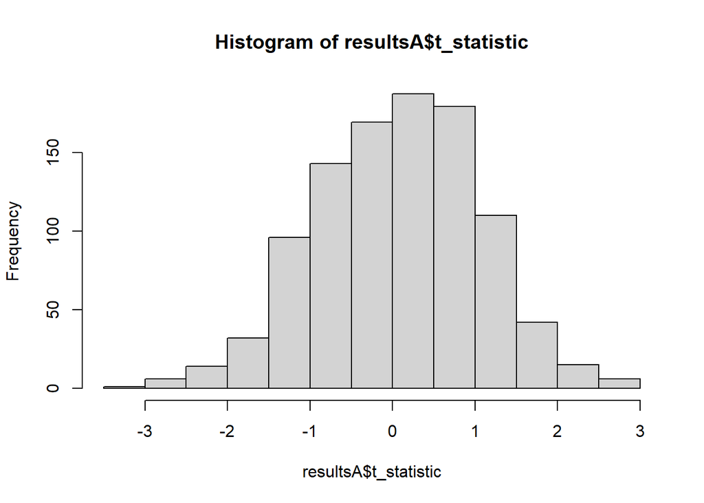

```r
hist(resultsA$t_statistic)
```

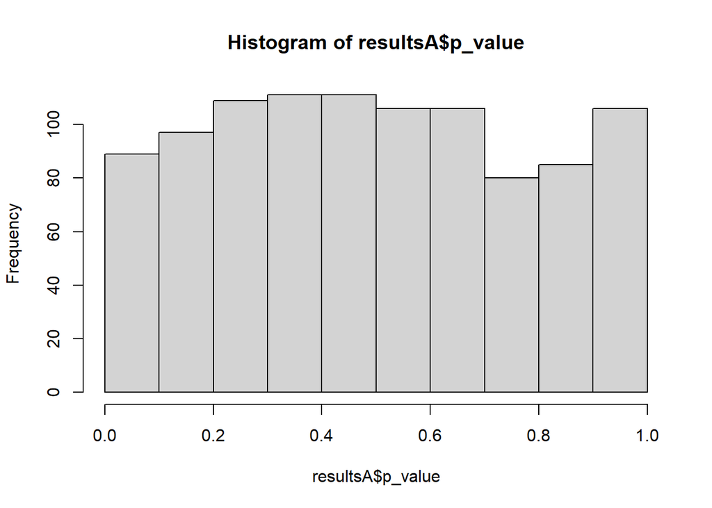

```r
hist(resultsA$p_value)
```

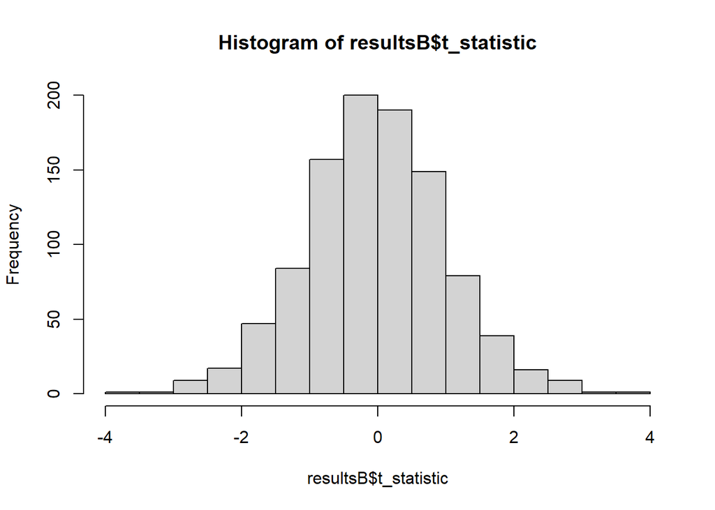

```r
hist(resultsB$t_statistic)
```

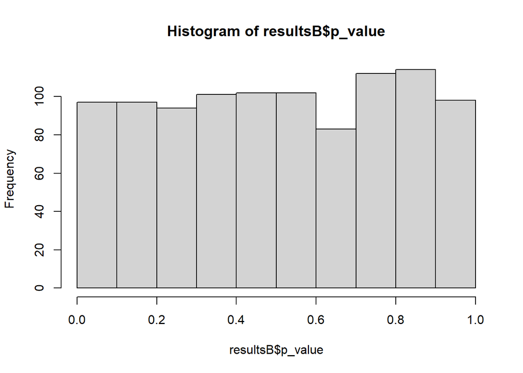

```r
hist(resultsB$p_value)
```

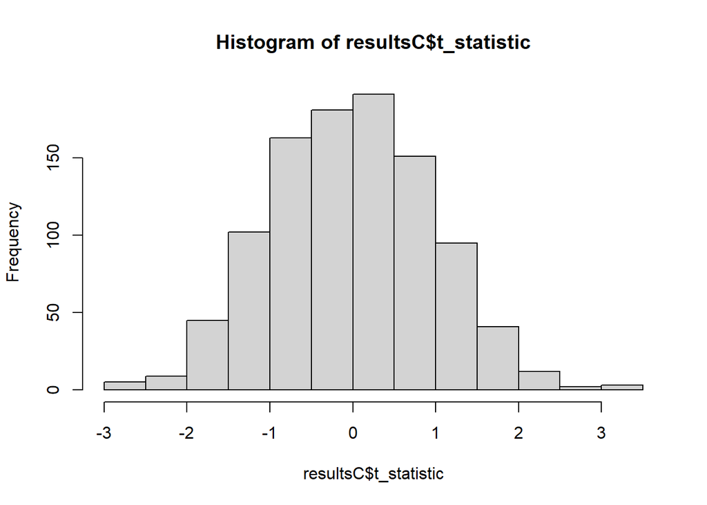

```r
hist(resultsC$t_statistic)
```

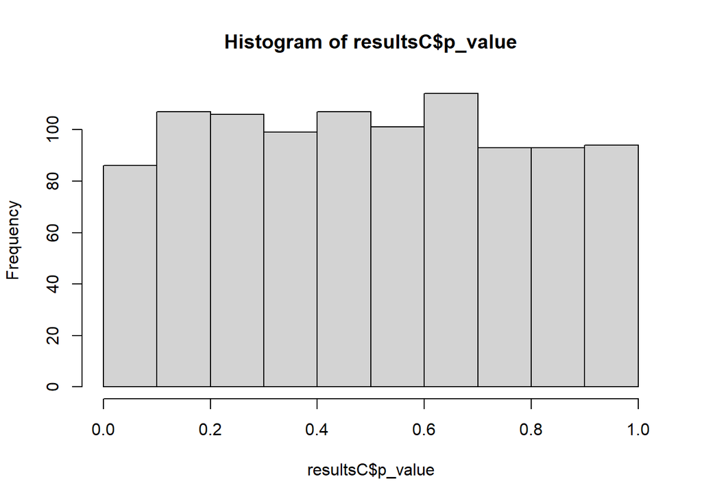

```r
hist(resultsC$p_value)
```

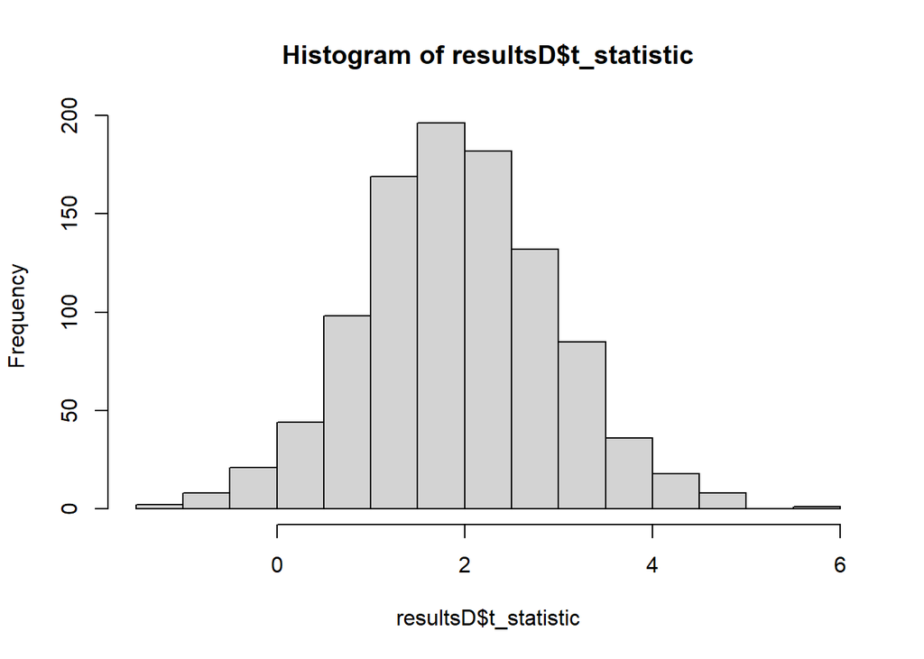

```r
hist(resultsD$t_statistic)
```

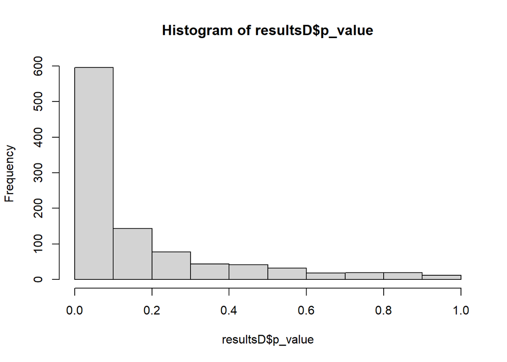

```r
hist(resultsD$p_value)
```

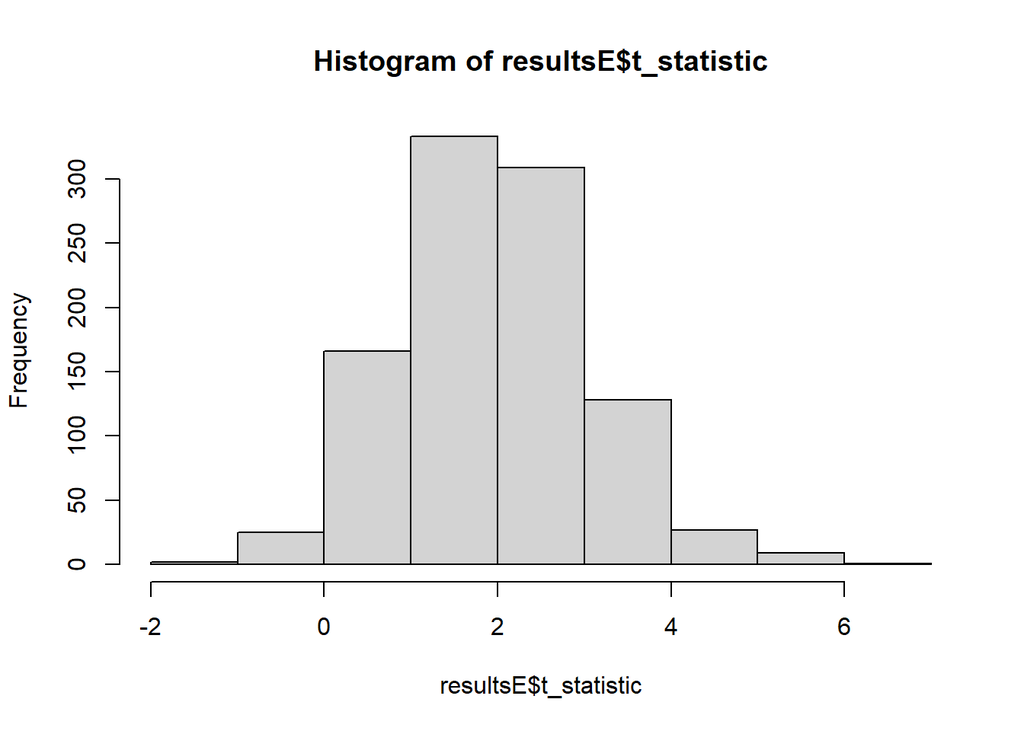

```r
hist(resultsE$t_statistic)
```

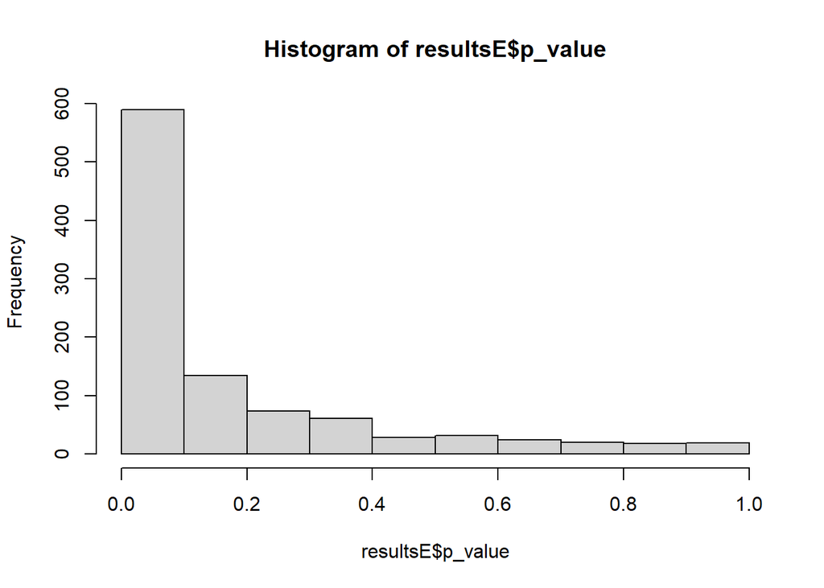

```r
hist(resultsE$p_value)
```

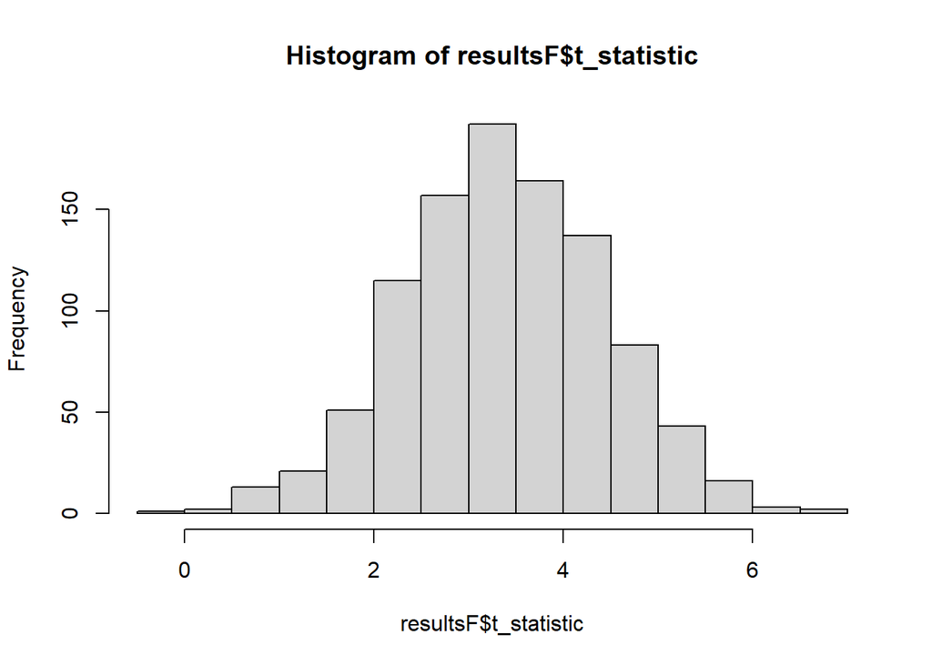

```r
hist(resultsF$t_statistic)
```

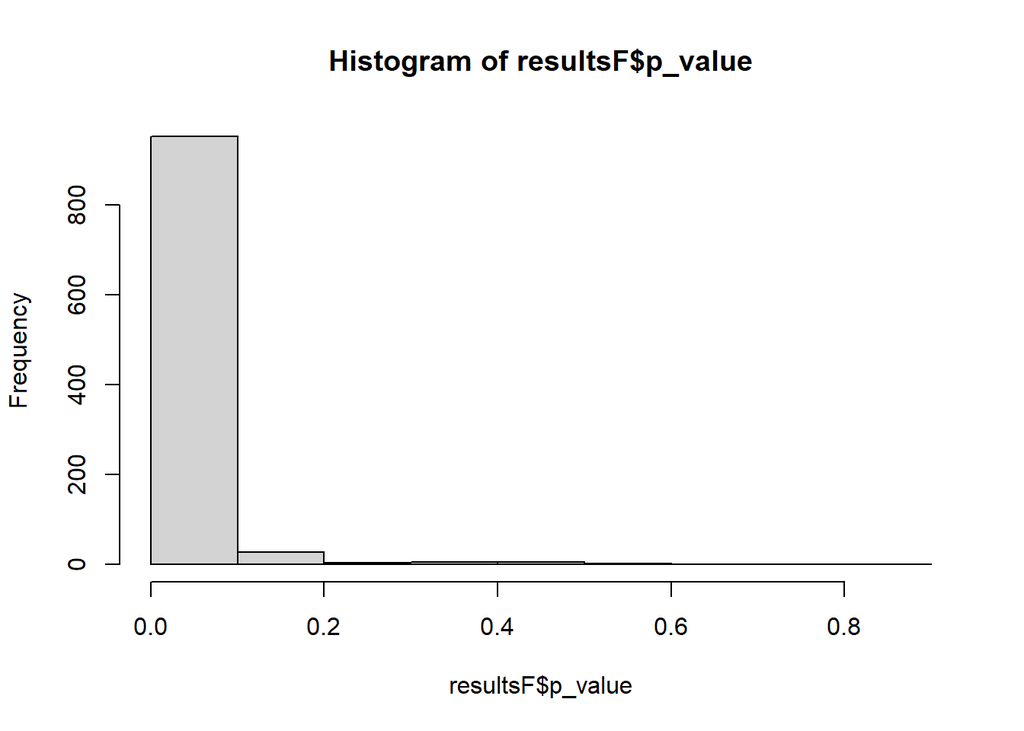

```r
hist(resultsF$p_value)
```

## Question 3

### B

When Ho is correct (according to the mean and SD that were selected - as in “resultsA”), the distribution becomes close to be uniformic distribution. However, when the H1 is correct (for example - “resultsD”) the distribution becomes more sided to the left, exponential distribution, hence - the more the p-value is getting bigger, so the probability of it is getting smaller.

### C

On the other hand, the distribution of “resultsF” versus “resultsD” shows a kind of demonstration of the statistical power that increases as the sample increases, in the case where there is an effect. The probability of obtaining a significant p-value increases significantly as the sample size increases. Accordingly, so does the probability for type 2 error decreases.

### D

The distributions in which the assumption of equality of variances was violated are “resultsB” (which we will compare to “resultsA”) and “resultsE” (which we will compare to “resultsD”, although the averages are not equal but in both cases there is an effect and the sample is the same, hence the general of the distribution as we saw in the previous section will be similar).

## Question 4

### A

```r
t_test_sim_welch <- function(M1, M2, S1, S2, N1, N2) {
  group_1 <- rnorm(N1, M1, S1)
  group_2 <- rnorm(N2, M2, S2)
  result <- t.test(group_1, group_2, alternative = "two.sided")
  t_statistic <- result$statistic
  p_value <- result$p.value
#  degrees_freedom <- result$parameter
#  print(degrees_freedom)
  return(data.frame(t_statistic, p_value))
}

t_test_sim_welch(0, 0, 1, 1, 30, 30)
```

```
##   t_statistic   p_value
## t  -0.6573804 0.5135536
```

```r
resultsA_welch <- data.frame(matrix(NA, ncol=2, nrow=1000))
colnames(resultsA_welch) <- c("t_statistic", "p_value")
resultsB_welch <- data.frame(matrix(NA, ncol=2, nrow=1000))
colnames(resultsB_welch) <- c("t_statistic", "p_value")
resultsC_welch <- data.frame(matrix(NA, ncol=2, nrow=1000))
colnames(resultsC_welch) <- c("t_statistic", "p_value")
resultsD_welch <- data.frame(matrix(NA, ncol=2, nrow=1000))
colnames(resultsD_welch) <- c("t_statistic", "p_value")
resultsE_welch <- data.frame(matrix(NA, ncol=2, nrow=1000))
colnames(resultsE_welch) <- c("t_statistic", "p_value")
resultsF_welch <- data.frame(matrix(NA, ncol=2, nrow=1000))
colnames(resultsF_welch) <- c("t_statistic", "p_value")

for (i in 1:1000){
  resultsA_welch[i,] <- t_test_sim_welch(0, 0, 1, 1, 30, 30)
  resultsB_welch[i,] <- t_test_sim_welch(0, 0, 1, 3, 30, 30)
  resultsC_welch[i,] <- t_test_sim_welch(0, 0, 1, 1, 90, 90)
  resultsD_welch[i,] <- t_test_sim_welch(0.5, 0, 1, 1, 30, 30)
  resultsE_welch[i,] <- t_test_sim_welch(sqrt(5) * 0.5, 0, 1, 3, 30, 30)
  resultsF_welch[i,] <- t_test_sim_welch(0.5, 0, 1, 1, 90, 90)
}
```

### B

```r
t_test_sim_ourQuest <- function(M1, M2, S1, S2, N1, N2) {
  sample_1 <- rnorm(N1, M1, S1)
  sample_2 <- rnorm(N2, M2, S2)
  result <- t.test(sample_1, sample_2, alternative = "two.sided",
                   var.equal = TRUE, paired = TRUE)
  t_statistic <- result$statistic
  p_value <- result$p.value
  return(data.frame(t_statistic, p_value))
}
```

```r
t_test_sim_gup_between_M <- function(M1, M2, S1, S2, N1, N2) {
  sample_1 <- rnorm(N1, M1, S1)
  sample_2 <- rnorm(N2, M2, S2)
  result <- t.test(sample_2-sample_1, alternative = "two.sided", var.equal = TRUE)
  print(result)
  t_statistic <- result$statistic
  p_value <- result$p.value
  return(data.frame(t_statistic, p_value))
}
```

```r
resultsA_ourQuest <- data.frame(matrix(NA, ncol=2, nrow=1000))
colnames(resultsA_ourQuest) <- c("t_statistic", "p_value")
resultsB_ourQuest <- data.frame(matrix(NA, ncol=2, nrow=1000))
colnames(resultsB_ourQuest) <- c("t_statistic", "p_value")
resultsC_ourQuest <- data.frame(matrix(NA, ncol=2, nrow=1000))
colnames(resultsC_ourQuest) <- c("t_statistic", "p_value")
resultsD_ourQuest <- data.frame(matrix(NA, ncol=2, nrow=1000))
colnames(resultsD_ourQuest) <- c("t_statistic", "p_value")

for (i in 1:1000){
  resultsA_ourQuest[i,] <- t_test_sim_gup_between_M(0, 0, 1, 1, 30, 30)
  resultsB_ourQuest[i,] <- t_test_sim_ourQuest(0, 0, 1, 1, 30, 30)
  resultsC_ourQuest[i,] <- t_test_sim_gup_between_M(10, 0, 1, 1, 90, 90)
  resultsD_ourQuest[i,] <- t_test_sim_ourQuest(10, 0, 1, 1, 90, 90)
}
```

[output not shown]

[output cut: 23944 more lines]

[output not shown]

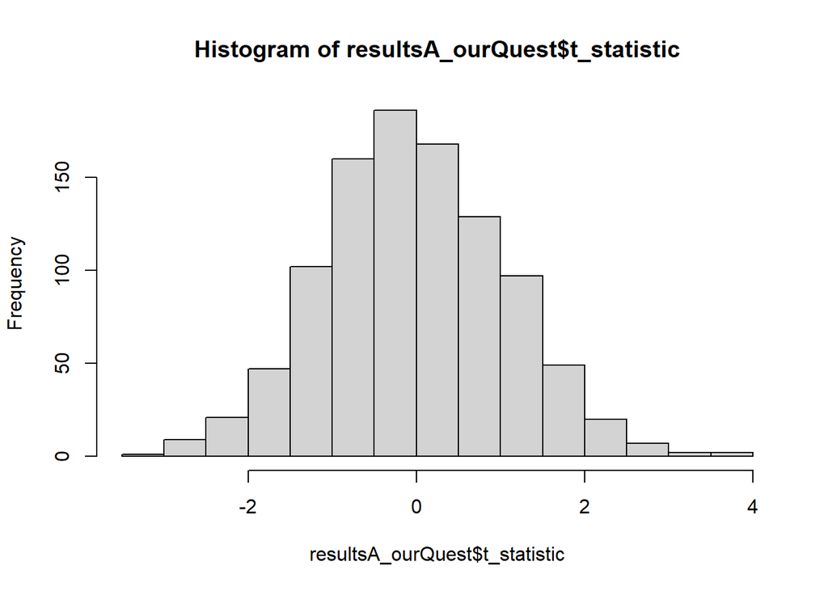

```r
hist(resultsA_ourQuest$t_statistic)
```

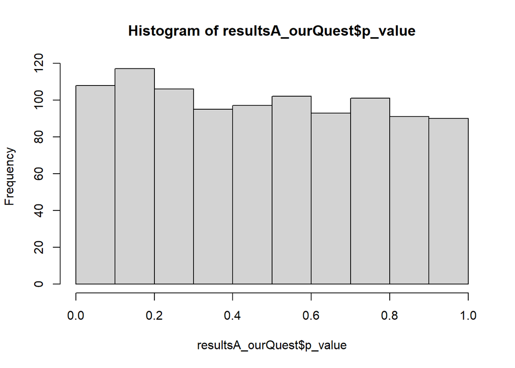

```r
hist(resultsA_ourQuest$p_value)
```

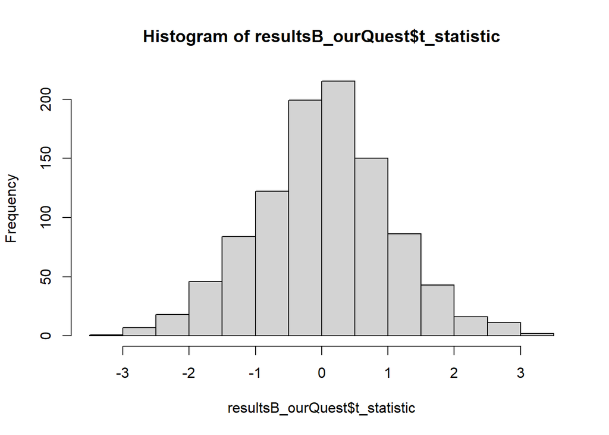

```r
hist(resultsB_ourQuest$t_statistic)
```

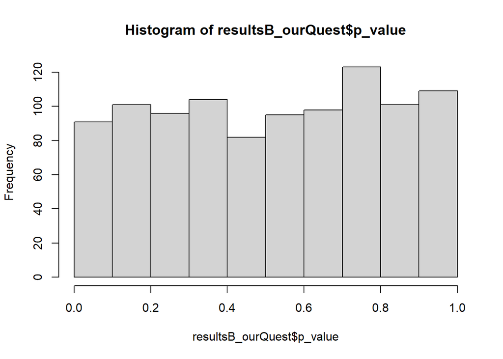

```r
hist(resultsB_ourQuest$p_value)
```

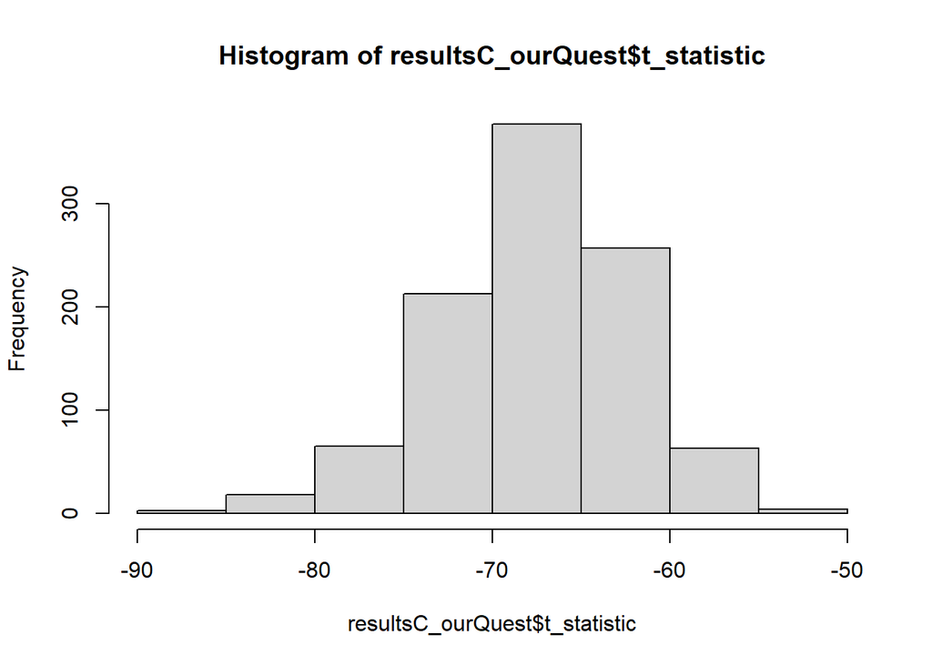

```r
hist(resultsC_ourQuest$t_statistic)
```

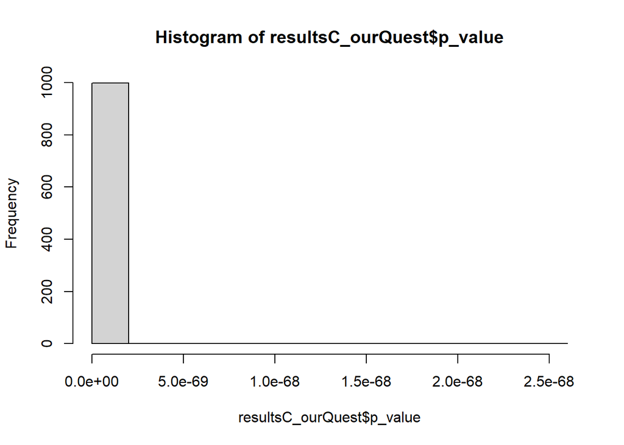

```r
hist(resultsC_ourQuest$p_value)
```

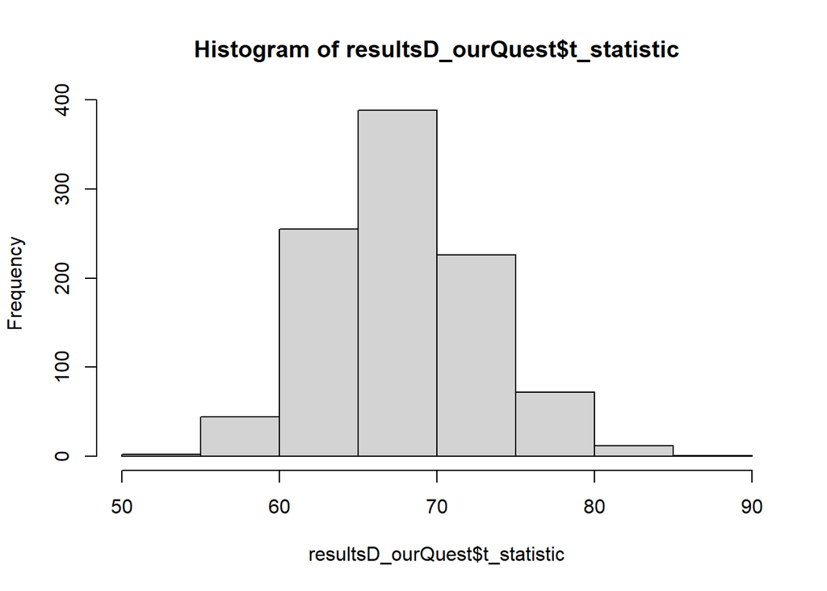

```r
hist(resultsD_ourQuest$t_statistic)
```

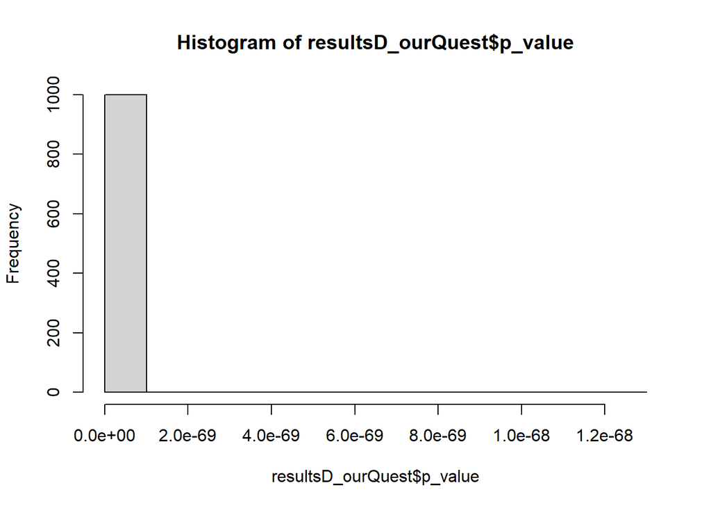

```r
hist(resultsD_ourQuest$p_value)
```

In our question, we tried to check whether the gup of averages between two groups is indeed equivalent to the assignment of the argument “paired = TRUE” in the t-test function of R, hence - to paired sample t-test . We have seen that the results of the simulations in both tests (a t-test on a single sample of mean difference versus a t-test defined for paired samples) are indeed very similar, and there does not seem to be a significant difference, in a manner consistent with the principle taught in class.